# part C

2084551

30/05/2021

```r
knitr::opts_chunk$set(echo = TRUE, warning = FALSE, message = FALSE)
```

# Data Preparation

```r
rm(list=ls())
library(ggplot2)
library(dplyr)
library(tidytext)
library(jsonlite)
library(tidyr)
library(readr)
library(topicmodels)
library(geojsonR)
library(stringr)
library(dplyr)
library(tidyr)
library(stm)
library(udpipe)
library(cld2)
library(wordcloud)
library(xml2)
library(rvest)
set.seed(123113)
```

Download the dataset from airbnb.com

```r
#crawl data from the website
path <- "http://insideairbnb.com/get-the-data.html"

#table preparation
data_set <- read_html(path)
list_of_tables <- data_set %>% html_nodes("table")

#City index for New York is 63.
city_index <- 63
table <-list_of_tables[[city_index]] %>% html_table()

#Getting the links to download the data
links <- list_of_tables[[city_index]] %>% html_nodes("a") %>% html_attr("href")

# Add it on the dataframe
table$links <- links

# cleaning the column names (lower case, replace _with spaces)
colnames(table) <- gsub(" ","_",tolower(colnames(table)))
colnames(table) <- gsub("/","_",colnames(table))

# Convert the date to a date using the as.Date function.
table$date_compiled <- as.Date(table$date_compiled,format = "%d %b,%Y")
```

```r
# Get Review Data
Review_data <- table %>% arrange(desc(date_compiled)) %>%
  filter(grepl("Detailed Review",description)) %>%
  top_n(1)

# Get Listings Data
Listings_data <- table %>% arrange(desc(date_compiled)) %>%
  filter(grepl("Detailed Listings",description)) %>%
  top_n(1)
```

```r
#download the files

NYC <- tolower(Listings_data$country_city[1])

download.file(url = Listings_data$links[1],destfile = "listings.csv.gz")

download.file(url = Review_data$links[1], destfile = "reviews.csv.gz")
```

```r
listings_detailed <- readr::read_csv("listings.csv.gz")
reviews_detailed <- readr::read_csv("reviews.csv.gz")

listings_detailed <- listings_detailed %>% rename(listing_id = id)
```

## Cleaning for Review file

```r
# Check the data structure of review file
str(reviews_detailed)
```

```
## spec_tbl_df [836,586 x 6] (S3: spec_tbl_df/tbl_df/tbl/data.frame)
##  $ listing_id   : num [1:836586] 2595 2595 2595 2595 2595 ...
##  $ id           : num [1:836586] 17857 19176 19760 34320 46312 ...
##  $ date         : Date[1:836586], format: "2009-11-21" "2009-12-05" ...
##  $ reviewer_id  : num [1:836586] 50679 53267 38960 71130 117113 ...
##  $ reviewer_name: chr [1:836586] "Jean" "Cate" "Anita" "Kai-Uwe" ...
##  $ comments     : chr [1:836586] "Notre séjour de trois nuits.\r\nNous avons apprécier L'appartement qui est très bien situé. Agréable, propre et"| __truncated__ "Great experience." "I've stayed with my friend at the Midtown Castle for six days and it was a lovely place to be. A big spacious r"| …
##  - attr(*, "spec")=
##   .. cols(
##   ..   listing_id = col_double(),
##   ..   id = col_double(),
##   ..   date = col_date(format = ""),
##   ..   reviewer_id = col_double(),
##   ..   reviewer_name = col_character(),
##   ..   comments = col_character()
##   .. )
```

```r
reviews_detailed$date <- as.Date(reviews_detailed$date)

# Filtering out reviews after feb 2020 from reviews_detailed dataset
(records_per_year <- reviews_detailed %>% group_by(lubridate::year(date)) %>% summarise(count = n()))
```

```
## # A tibble: 13 x 2
##    `lubridate::year(date)`  count
##                      <dbl>  <int>
##  1                    2009     93
##  2                    2010    696
##  3                    2011   2952
##  4                    2012   6176
##  5                    2013  11845
##  6                    2014  23391
##  7                    2015  46326
##  8                    2016  80251
##  9                    2017 115833
## 10                    2018 170301
## 11                    2019 239223
## 12                    2020 106937
## 13                    2021  32562
```

```r
reviews_pre_corona <- reviews_detailed %>% filter(date<"2020-02-01")
head(reviews_pre_corona)
```

```
## # A tibble: 6 x 6
##   listing_id      id date       reviewer_id reviewer_name comments
##        <dbl>   <dbl> <date>           <dbl> <chr>         <chr>
## 1       2595   17857 2009-11-21       50679 Jean          "Notre séjour de troi~
## 2       2595   19176 2009-12-05       53267 Cate          "Great experience."
## 3       2595   19760 2009-12-10       38960 Anita         "I've stayed with my ~
## 4       2595   34320 2010-04-09       71130 Kai-Uwe       "We've been staying h~
## 5       2595   46312 2010-05-25      117113 Alicia        "We had a wonderful s~
## 6       2595 1238204 2012-05-07     1783688 Sergey        "Hi to everyone!\r\nW~
```

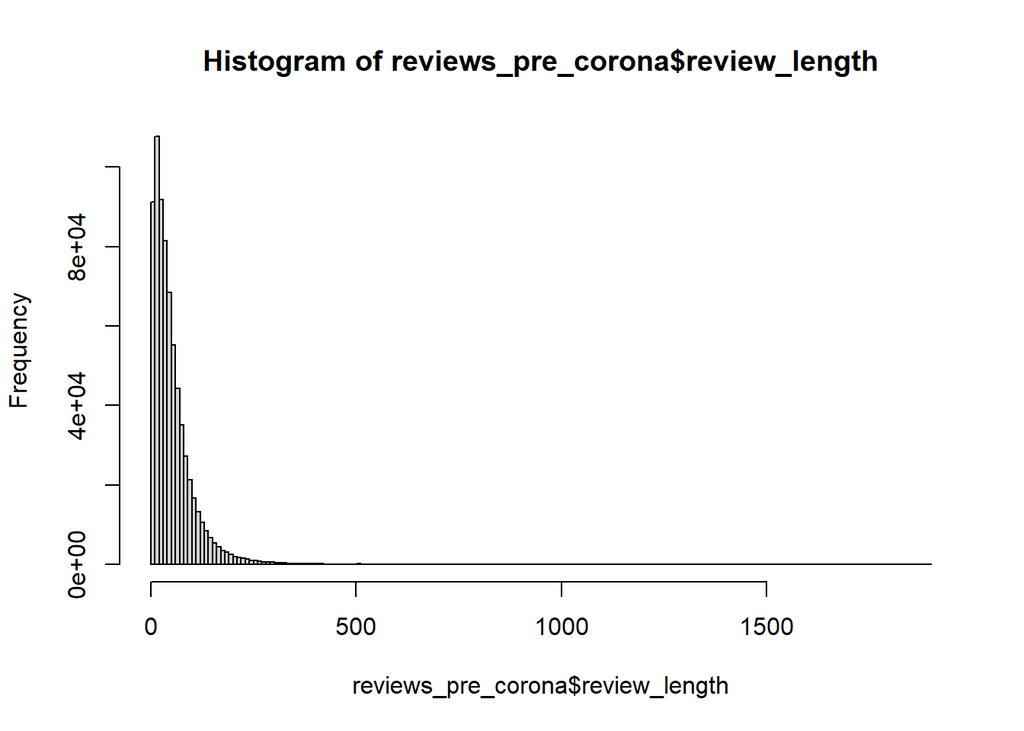

```r
# Step 1

#finding the number of words in each review so that we can filter out reviews with very few words. this will improve the accuracy of language detection
reviews_pre_corona$comments <- iconv(reviews_pre_corona$comments)

reviews_pre_corona$review_length <- sapply(reviews_pre_corona$comments, function(x) length(unlist(strsplit(as.character(x), "\\W+"))))

hist(reviews_pre_corona$review_length, breaks = 200)
```

```r
summary(reviews_pre_corona$review_length)
```

```
##    Min. 1st Qu.  Median    Mean 3rd Qu.    Max.
##    1.00   18.00   39.00   53.15   69.00 1900.00
```

```r
#select the lower limit as 15 and upper as 300

reviews_pre_corona <- reviews_pre_corona %>%
  filter(review_length>14) %>%
  filter(review_length<301)


# Now we are ready to Clean up the language
# For some computers the character set is not
# automatically set to latin or ASCII
library(cld2)
#reviews_pre_corona$comments <- iconv(reviews_pre_corona$comments)
reviews_pre_corona$language <- cld2::detect_language(reviews_pre_corona$comments)
reviews_pre_corona%>%
  filter(language =="en") -> reviews_pre_corona

reviews_pre_corona$language <- NULL
reviews_pre_corona <- reviews_pre_corona %>%
  rename("review_id"="id")
```

```r
englishmodel <- udpipe::udpipe_download_model("english")

englishmodel <- udpipe::udpipe_load_model(englishmodel$file_model)
```

```r
#join the listings and reviews to get the review score rating

#prepare reviews_pre_corona to left join with listing.

reviews_pre_corona_metadata <- reviews_pre_corona

reviews_pre_corona <- reviews_pre_corona %>%
  group_by(listing_id) %>%
  summarise(comments_grouped = paste(comments, collapse = " "))

reviews_joined <- reviews_pre_corona_metadata %>%
  left_join(reviews_pre_corona)


listing_reviews <- listings_detailed %>%
  inner_join(reviews_joined)
```

```r
# library(udpipe)
#
# # No need if you have already downloaded it once
# language <- udpipe_download_model(language="english",overwrite = F)
# ud_model <- udpipe_load_model(language)
#
# annotated_reviews_all <- data.frame()
#

#
#
# split_size <- 1000
#
# for_pos_list <- split(data_for_stm,
#                      rep(1:ceiling(nrow(data_for_stm)
#                                    /split_size),
#                          each=split_size,
#                          length.out=nrow(data_for_stm)))
#
#
#
# for(i in 1:length(for_pos_list)){
# #for(i in 1:10){
#
#     udpipe_annotate(for_pos_list[[i]]$comments,
#                 doc_id = for_pos_list[[i]]$review_id,
#                 object= ud_model) %>%
#     as.data.frame() %>%
#     filter(upos %in% c("NOUN","ADJ","ADV")) %>%
#     select(doc_id,lemma) %>%
#     group_by(doc_id) %>%
#     summarise(annotated_comments = paste(lemma, collapse = " ")) %>%
#     rename(review_id = doc_id) -> this_annotated_reviews
#
#   print(paste(i,"from",length(for_pos_list)))
#   annotated_reviews_all <- bind_rows(annotated_reviews_all,
#                                      this_annotated_reviews)
# }
#
# #}
#
# write.csv(annotated_reviews_all,"F:\\WBS\\Term 3\\Text Analytics\\Assignment\\New York\\Data_NY\\Part C\\annotated_reviews.csv", row.names = FALSE)
```

```r
# select the relevant columns for joining with the annotated reviews
data <- listing_reviews %>%
  dplyr::select(review_id, comments, review_scores_rating,listing_id,
         price,date, neighbourhood_cleansed) %>%
  mutate(price = as.numeric(gsub("\\$|,","",price)))


annotated_reviews_all <- readr::read_csv("F:\\WBS\\Term 3\\Text Analytics\\Assignment\\New York\\Data_NY\\Part C\\annotated_reviews.csv")

annotated_reviews_all$review_id <- as.integer(annotated_reviews_all$review_id)
#left join the annotated reviews with the columns from the main dataset.
dataprep <- annotated_reviews_all %>%
  left_join(data)
```

## Neighborhood level of aggregation

```r
# Prepare metadata for the STM model
#Ensuring that the price is numeric.
dataprep$price <- gsub("\\$|,","",dataprep$price)
dataprep$price <- as.numeric(dataprep$price)

#creating mean rating and mean price columns per neighborhood.
data_for_stm <- dataprep %>%
  group_by(neighbourhood_cleansed) %>%
  summarise(comments_grouped_neigh = paste(annotated_comments, collapse = " "), mean_rating = mean(review_scores_rating), mean_price = mean(price))


data_for_stm <- data_for_stm %>% na.omit()
data_for_stm$rownum <- 1:nrow(data_for_stm)
#Use textprocessor function to remove stopwords and custom stopwords

text <- textProcessor(data_for_stm$comments_grouped_neigh,
                           metadata = data_for_stm,
                           customstopwords = c("neighborhood",
                "manhattan",
                "located",
                "brooklyn",
                "queens",
                "staten",
                "island",
                "bronx",
                "stay",
                "staying",
                "airbnb",
                "line",
                "much",
                "min",
                "also","location", "apartment", "suite", "place", "host", "great","clean"),removestopwords = TRUE
                           ,stem = F)
```

```
## Building corpus...
## Converting to Lower Case...
## Removing punctuation...
## Removing stopwords...
## Remove Custom Stopwords...
## Removing numbers...
## Creating Output...
```

```r
# Remove words that appear in less than 1% of the corpus
thresh <- round(1/100 * length(text$documents),0)

output <- prepDocuments(text$documents,
                     text$vocab,
                     text$meta,
                     lower.thresh = thresh)
```

```
## Removing 27811 of 42139 terms (32588 of 408220 tokens) due to frequency
## Your corpus now has 207 documents, 14328 terms and 375632 tokens.
```

```r
# numtopics <- searchK(output$documents,output$vocab,K=seq(from=6, to=14,by=1))
# plot(numtopics)
```

```r
#Run the stm function to get the 12 topics that we want.
newyorkfit <- stm(documents = output$documents,
                   vocab = output$vocab,
                   K = 12,
                   prevalence = ~mean_rating + mean_price,
                   max.em.its = 75,
                   data = output$meta,
                   reportevery=3,
                   # gamma.prior = "L1",
                   sigma.prior = 0.7,
                   init.type = "Spectral")
```

```
## Beginning Spectral Initialization
##   Calculating the gram matrix...
##   Using only 10000 most frequent terms during initialization...
##   Finding anchor words...
##      ............
##   Recovering initialization...
##      ....................................................................................................
## Initialization complete.
## .......................................................................................................
## Completed E-Step (1 seconds).
## Completed M-Step.
## Completing Iteration 1 (approx. per word bound = -6.549)
## .......................................................................................................
## Completed E-Step (0 seconds).
## Completed M-Step.
## Completing Iteration 2 (approx. per word bound = -6.521, relative change = 4.251e-03)
## .......................................................................................................
## Completed E-Step (0 seconds).
## Completed M-Step.
## Completing Iteration 3 (approx. per word bound = -6.509, relative change = 1.989e-03)
## Topic 1: room, nice, subway, comfortable, really
##  Topic 2: comfortable, just, definitely, many, safe
##  Topic 3: room, time, perfect, nice, good
##  Topic 4: beach, nice, comfortable, perfect, time
##  Topic 5: subway, nice, really, room, comfortable
##  Topic 6: room, nice, subway, good, time
##  Topic 7: nice, home, definitely, comfortable, room
##  Topic 8: perfect, restaurant, comfortable, nice, really
##  Topic 9: nice, room, comfortable, definitely, house
##  Topic 10: subway, nice, room, really, good
##  Topic 11: subway, room, nice, really, time
##  Topic 12: nice, comfortable, room, subway, home
## .......................................................................................................
## Completed E-Step (0 seconds).
## Completed M-Step.
## Completing Iteration 4 (approx. per word bound = -6.503, relative change = 7.806e-04)
## .......................................................................................................
## Completed E-Step (0 seconds).
## Completed M-Step.
## Completing Iteration 5 (approx. per word bound = -6.501, relative change = 3.612e-04)
```

[output cut: 61 more lines]

```
##  Topic 10: subway, nice, comfortable, really, close
##  Topic 11: subway, room, nice, really, time
##  Topic 12: comfortable, subway, restaurant, nice, home
## .......................................................................................................
## Completed E-Step (0 seconds).
## Completed M-Step.
## Completing Iteration 13 (approx. per word bound = -6.498, relative change = 1.237e-05)
## .......................................................................................................
## Completed E-Step (0 seconds).
## Completed M-Step.
## Completing Iteration 14 (approx. per word bound = -6.498, relative change = 1.040e-05)
## .......................................................................................................
## Completed E-Step (0 seconds).
## Completed M-Step.
## Model Converged
```

```r
summary(newyorkfit)
```

```
## A topic model with 12 topics, 207 documents and a 14328 word dictionary.
```

```
## Topic 1 Top Words:
##       Highest Prob: room, nice, comfortable, subway, really, good, time
##       FREX: tram, campus, hospital, victor, cloister, river, medical
##       Lift: oculus, stackable, undoubtly, manhatthan, sunnyside, relentlessly, ester
##       Score: room, train, cloister, sunnyside, trish, subway, building
## Topic 2 Top Words:
##       Highest Prob: comfortable, safe, definitely, just, many, cozy, couple
##       FREX: reason, glad, message, couple, quickly, many, safe
##       Lift: reason, monica, intimately, glad, outcome, defininitely, bogeda
##       Score: reason, safe, many, couple, cozy, quickly, message
## Topic 3 Top Words:
##       Highest Prob: room, time, perfect, nice, good, comfortable, really
##       FREX: staff, square, theater, theatre, doorman, show, district
##       Lift: javit, rockerfeller, ucuceuac, macys, martini, ktown, unlivable
##       Score: building, chelsea, perfect, square, highline, central, doorman
## Topic 4 Top Words:
##       Highest Prob: ferry, beach, nice, house, time, comfortable, perfect
##       FREX: beach, ferry, boat, boardwalk, cottage, bungalow, ocean
##       Lift: dolphin, rockaways, beachy, nautical, houseboat, birder, wharf
##       Score: ferry, beach, houseboat, boardwalk, marina, cottage, boat
## Topic 5 Top Words:
##       Highest Prob: nice, subway, really, room, comfortable, easy, time
##       FREX: brownstone, bodega, stuy, neighbourhood, peaches, peach, cafe
##       Lift: stuy, peaches, oxtail, bedford, bushwick, putnam, renee
##       Score: brownstone, subway, peaches, stuy, train, really, station
## Topic 6 Top Words:
##       Highest Prob: room, nice, subway, good, really, close, time
##       FREX: chinese, stadium, diverse, asian, budget, game, station
##       Lift: woodside, herman, coxy, dominant, partement, malaysian, luz
##       Score: room, train, subway, station, house, good, minute
## Topic 7 Top Words:
##       Highest Prob: home, nice, definitely, comfortable, time, house, really
##       FREX: juice, fruit, snack, egg, milk, driveway, caribbean
##       Lift: emaculately, arrea, yonker, trini, kureig, pple, vie
##       Score: home, house, parking, driveway, caribbean, bus, snack
## Topic 8 Top Words:
##       Highest Prob: perfect, restaurant, really, comfortable, nice, easy, time
##       FREX: village, loft, east, bar, west, lower, nightlife
##       Lift: bdfm, bleeker, loath, nyu, villiage, orchard, delancey
##       Score: bar, village, restaurant, soho, loft, perfect, east
## Topic 9 Top Words:
##       Highest Prob: nice, room, comfortable, definitely, home, house, close
##       FREX: airport, layover, flushing, overnight, flight, lirr, basement
##       Lift: hospitalization, acres, bayside, confort�vel, aditionally, shirley, layover
##       Score: airport, layover, flushing, bus, flight, house, driveway
## Topic 10 Top Words:
##       Highest Prob: subway, nice, comfortable, good, really, close, time
##       FREX: museum, upper, east, met, central, side, green
##       Lift: streak, ues, astoria, ditmar, guggenheim, aldi, geoff
##       Score: subway, restaurant, museum, astoria, block, ues, east
## Topic 11 Top Words:
##       Highest Prob: subway, room, nice, really, time, comfortable, good
##       FREX: harlem, express, downtown, agnes, north, jazz, uptown
##       Lift: trinity, agnes, confronting, sylvia, uueuufuuau, uueuuuufuuuucudu, lasting
##       Score: harlem, agnes, subway, brownstone, downtown, room, express
## Topic 12 Top Words:
##       Highest Prob: comfortable, subway, restaurant, nice, home, easy, perfect
##       FREX: brownstone, garden, prospect, tree, toy, slope, park
##       Lift: bergen, pre-wedding, brookling, parkslope, bergan, barbes, threes
##       Score: brownstone, prospect, restaurant, pierce, shop, beautiful, subway
```

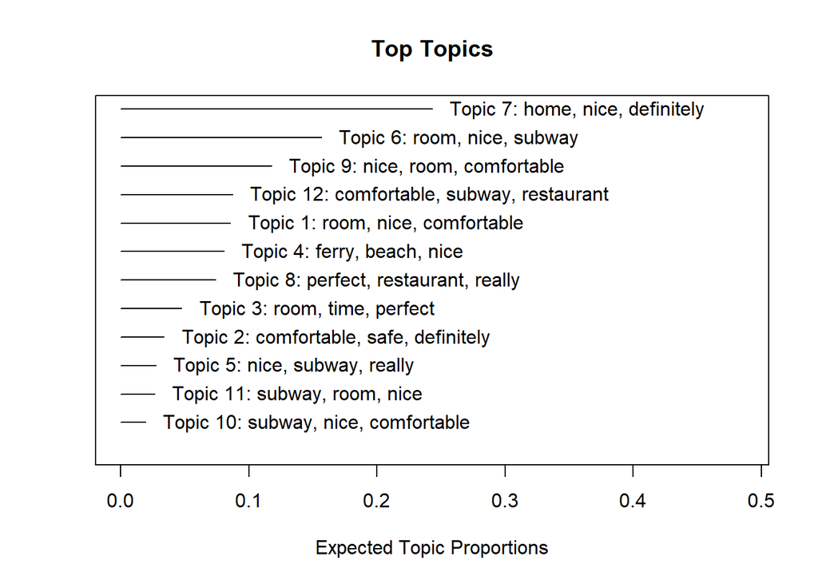

```r
plot(newyorkfit)
```

```r
newyorkfit_topics<-tidy(newyorkfit,matrix="beta")
```

```r
#We get the top 10 terms:

newyorkfit_terms<-newyorkfit_topics %>%
  group_by(topic) %>%
  slice_max(beta,n=10) %>%
  ungroup() %>%
  arrange(topic,desc(beta))
newyorkfit_terms
```

```
## # A tibble: 120 x 3
##    topic term          beta
##    <int> <chr>        <dbl>
##  1     1 room        0.0262
##  2     1 nice        0.0204
##  3     1 comfortable 0.0150
##  4     1 subway      0.0144
##  5     1 really      0.0129
##  6     1 good        0.0125
##  7     1 time        0.0124
##  8     1 close       0.0115
##  9     1 train       0.0109
## 10     1 easy        0.0106
## # ... with 110 more rows
```

*Topic labeling*

```r
#we look at the most frequent words appearing in each topic and give a name to each topic.
topic_labels <- c("Proximity to Subway", "Comfiness & coziness","Room check in time","Closeness to ferry and beach", "Comfort of the room", "Niceness of the room", "Spaciousness of home", "Restaurants near the listing", "Comfort of the house", "Quality of restuarants nearby","Comfort of reaching subway","Perfect resturants nearby")
```

And we can plot the results:

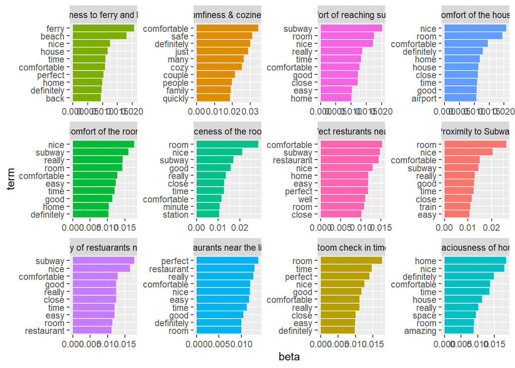

```r
#Creat a column to name the topics.
newyorkfit_terms <-  newyorkfit_terms %>%
 mutate(topic_label = case_when((topic == 1) ~ topic_labels[1],
                                (topic == 2) ~ topic_labels[2],
                                (topic == 3) ~ topic_labels[3],
                                (topic == 4) ~ topic_labels[4],
                                (topic == 5) ~ topic_labels[5],
                                (topic == 6) ~ topic_labels[6],
                                (topic == 7) ~ topic_labels[7],
                                (topic == 8) ~ topic_labels[8],
                                (topic == 9) ~ topic_labels[9],
                                (topic == 10) ~ topic_labels[10],
                                (topic == 11) ~ topic_labels[11],
                                (topic == 12) ~ topic_labels[12]))


newyorkfit_terms %>%
mutate(term = reorder_within(term, beta, topic)) %>%
ggplot(aes(beta, term, fill = factor(topic))) +
geom_col(show.legend = FALSE) +
facet_wrap(~ topic_label, scales = "free") +
scale_y_reordered()
```

```r
#install.packages("wordcloud")
library(wordcloud)
# stm::cloud(newyorkfit,topic = 1)
# stm::cloud(newyorkfit,topic = 2)
# stm::cloud(newyorkfit,topic = 3)
# stm::cloud(newyorkfit,topic = 4)
# stm::cloud(newyorkfit,topic = 5)
# stm::cloud(newyorkfit,topic = 6)
# stm::cloud(newyorkfit,topic = 7)
# stm::cloud(newyorkfit,topic = 8)
```

```r
gamma_topics<-tidy(newyorkfit,matrix="gamma")
#pivot the gamma_topics
gamma_topics<-gamma_topics %>%
  pivot_wider(names_from=topic,values_from=gamma)

topic_labels <- paste0("topic_",1:12)
colnames(gamma_topics)<-c("document",topic_labels)

rownames(gamma_topics) <- gamma_topics$document
```

```r
gamma_topics$document <- NULL
gamma_topics<-as.data.frame(gamma_topics)
head(gamma_topics)
```

```
##        topic_1     topic_2      topic_3     topic_4      topic_5      topic_6
## 1 0.0009040755 0.052111993 0.0015496820 0.001564376 8.792515e-03 2.134715e-01
## 2 0.0001227789 0.013496545 0.0612907623 0.033758830 2.692640e-04 6.269883e-01
## 3 0.0277530156 0.093451706 0.0019620580 0.295557704 5.785120e-04 1.112041e-01
## 4 0.0471467424 0.005256529 0.0000619471 0.913020549 3.915277e-05 2.141963e-05
## 5 0.0530623547 0.016803928 0.0001663602 0.009483750 1.422739e-02 3.477360e-01
## 6 0.0093283088 0.085686159 0.0002914644 0.053285631 5.650643e-02 2.273566e-01
##        topic_7      topic_8      topic_9     topic_10     topic_11     topic_12
## 1 0.6789053168 0.0008909546 0.0008120950 2.790146e-02 0.0005193678 0.0125766401
## 2 0.0003377518 0.0087188141 0.2526262227 1.688447e-03 0.0005945110 0.0001077546
## 3 0.3324846767 0.0011784056 0.1250569011 2.005200e-03 0.0004497273 0.0083179518
## 4 0.0005971949 0.0001864113 0.0313910625 1.892094e-05 0.0000150557 0.0022450148
## 5 0.0157252059 0.0003390068 0.0004400003 5.102165e-01 0.0001276188 0.0316718903
## 6 0.4553719117 0.0121888581 0.0640574642 9.362946e-04 0.0008950375 0.0340958017
```

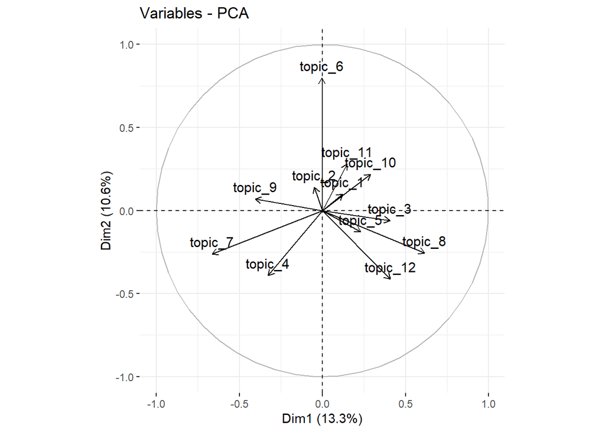

```r
#Run PCA and plot the Biplot
#install.packages("factoextra")
library(factoextra)
pcah2 <- FactoMineR::PCA(gamma_topics,graph = FALSE)
factoextra::fviz_pca_var(pcah2)
```

*Expected topic proportions*

extract the theta matrix from the fitted object

```r
convergence_theta <- as.data.frame(newyorkfit$theta)

topic_summary <- summary(newyorkfit)
```

```
## A topic model with 12 topics, 207 documents and a 14328 word dictionary.
```

```r
topic_proportions <- colMeans(newyorkfit$theta)
```

```r
# Finding number  amenities, bathrooms,
i <- 1
for (i in 1:length(listings_detailed$host_verifications)) {

  listings_detailed$num_amenities[i] <- length(strsplit(listings_detailed$amenities[i], split= " ")[[1]])
  listings_detailed$num_bath[i] <- as.numeric(gsub("[^0-9.]", "",listings_detailed$bathrooms_text[i]))
    i <- i+1
}

all_sentiments <- readr::read_csv("sentiments.csv")

#joining listing data with the sentiments data. Before that we need to select the newly created columns to include in the regressions analysis.
join_data <- listings_detailed %>% dplyr::select(listing_id, neighbourhood_cleansed, num_bath,num_amenities,beds, room_type)

sentiment <- all_sentiments %>% left_join(join_data)
#Group by neighborhood and get a mean sentiment, mean beds, mean bathrooms and amenities.
sentiment <- sentiment %>%
  group_by(neighbourhood_cleansed) %>%
  summarise(avg_bing = mean(bing_liu_sentiment),
            avg_nrc = mean(nrc_sentiment),
            avg_afinn = mean(afinn_sentiment),
            avg_loughran = mean(loughran_sentiment),
            avg_bath = mean(num_bath),
            avg_beds = mean(beds),
            avg_amenities = mean(num_amenities))
sentiment <- sentiment %>% na.omit()
```

```r
stm_object<- newyorkfit$theta

colnames(stm_object) <- c("Proximity to Subway", "Comfiness & coziness","Room check in time","Closeness to ferry and beach", "Comfort of the room", "Niceness of the room", "Spaciousness of home", "Restaurants near the listing", "Comfort of the house", "Quality of restuarants nearby","Comfort of reaching subway","Perfect resturants nearby")

causal_topic_df <- cbind(output$meta,stm_object)

causal_topic_df %>%
  left_join(sentiment) %>%
  dplyr::select(-c(comments_grouped_neigh, neighbourhood_cleansed, rownum)) %>%
  na.omit() -> regress_stm_price_review
```

```r
model_search_review <- lm(mean_rating~.,data=regress_stm_price_review)
MASS::stepAIC(model_search_review)
```

Start: AIC=138.39 mean_rating ~ mean_price + `Proximity to Subway` + `Comfiness & coziness` + `Room check in time` + `Closeness to ferry and beach` + `Comfort of the room` + `Niceness of the room` + `Spaciousness of home` + `Restaurants near the listing` + `Comfort of the house` + `Quality of restuarants nearby` + `Comfort of reaching subway` + `Perfect resturants nearby` + avg_bing + avg_nrc + avg_afinn + avg_loughran + avg_bath + avg_beds + avg_amenities

Step: AIC=138.39 mean_rating ~ mean_price + `Proximity to Subway` + `Comfiness & coziness` + `Room check in time` + `Closeness to ferry and beach` + `Comfort of the room` + `Niceness of the room` + `Spaciousness of home` + `Restaurants near the listing` + `Comfort of the house` + `Quality of restuarants nearby` + `Comfort of reaching subway` + avg_bing + avg_nrc + avg_afinn + avg_loughran + avg_bath + avg_beds + avg_amenities

```
                              Df Sum of Sq    RSS    AIC
```

- avg_nrc 1 0.004 305.53 136.39
- avg_beds 1 0.021 305.55 136.40
- `Closeness to ferry and beach` 1 0.071 305.60 136.43
- `Comfiness & coziness` 1 0.116 305.64 136.46
- mean_price 1 0.158 305.68 136.48
- avg_bath 1 0.191 305.72 136.50
- `Spaciousness of home` 1 0.759 306.28 136.82
- avg_amenities 1 0.933 306.46 136.92
- `Comfort of reaching subway` 1 1.140 306.66 137.04
- `Proximity to Subway` 1 1.958 307.48 137.50
- `Comfort of the room` 1 2.642 308.17 137.88
- avg_loughran 1 3.013 308.54 138.09
- avg_afinn 1 3.545 309.07 138.39 305.52 138.39
- `Quality of restuarants nearby` 1 4.582 310.11 138.97
- `Restaurants near the listing` 1 6.105 311.63 139.81
- `Room check in time` 1 19.395 324.92 147.04
- avg_bing 1 19.942 325.47 147.33
- `Comfort of the house` 1 21.799 327.32 148.31
- `Niceness of the room` 1 34.188 339.71 154.74

Step: AIC=136.39 mean_rating ~ mean_price + `Proximity to Subway` + `Comfiness & coziness` + `Room check in time` + `Closeness to ferry and beach` + `Comfort of the room` + `Niceness of the room` + `Spaciousness of home` + `Restaurants near the listing` + `Comfort of the house` + `Quality of restuarants nearby` + `Comfort of reaching subway` + avg_bing + avg_afinn + avg_loughran + avg_bath + avg_beds + avg_amenities

```
                              Df Sum of Sq    RSS    AIC
```

- avg_beds 1 0.028 305.56 134.41
- `Closeness to ferry and beach` 1 0.067 305.60 134.43
- `Comfiness & coziness` 1 0.113 305.64 134.46
- mean_price 1 0.155 305.68 134.48
- avg_bath 1 0.188 305.72 134.50
- `Spaciousness of home` 1 0.760 306.29 134.82
- avg_amenities 1 0.941 306.47 134.93
- `Comfort of reaching subway` 1 1.195 306.72 135.07
- `Proximity to Subway` 1 1.956 307.48 135.50
- `Comfort of the room` 1 2.643 308.17 135.88
- avg_loughran 1 3.125 308.65 136.15
- avg_afinn 1 3.542 309.07 136.39 305.53 136.39
- `Quality of restuarants nearby` 1 4.582 310.11 136.97
- `Restaurants near the listing` 1 6.464 311.99 138.02
- `Room check in time` 1 19.625 325.15 145.16
- `Comfort of the house` 1 21.796 327.32 146.31
- avg_bing 1 32.914 338.44 152.09
- `Niceness of the room` 1 34.270 339.80 152.78

Step: AIC=134.41 mean_rating ~ mean_price + `Proximity to Subway` + `Comfiness & coziness` + `Room check in time` + `Closeness to ferry and beach` + `Comfort of the room` + `Niceness of the room` + `Spaciousness of home` + `Restaurants near the listing` + `Comfort of the house` + `Quality of restuarants nearby` + `Comfort of reaching subway` + avg_bing + avg_afinn + avg_loughran + avg_bath + avg_amenities

```
                              Df Sum of Sq    RSS    AIC
```

- `Closeness to ferry and beach` 1 0.061 305.62 132.44
- `Comfiness & coziness` 1 0.108 305.66 132.47
- mean_price 1 0.135 305.69 132.49
- avg_bath 1 0.219 305.77 132.53
- `Spaciousness of home` 1 0.757 306.31 132.84
- avg_amenities 1 0.924 306.48 132.93
- `Comfort of reaching subway` 1 1.246 306.80 133.11
- `Proximity to Subway` 1 2.024 307.58 133.55
- `Comfort of the room` 1 2.628 308.18 133.89
- avg_loughran 1 3.101 308.66 134.16
- avg_afinn 1 3.515 309.07 134.39 305.56 134.41
- `Quality of restuarants nearby` 1 4.634 310.19 135.01
- `Restaurants near the listing` 1 6.892 312.45 136.27
- `Room check in time` 1 20.369 325.93 143.57
- `Comfort of the house` 1 22.048 327.60 144.46
- avg_bing 1 33.522 339.08 150.42
- `Niceness of the room` 1 34.941 340.50 151.14

Step: AIC=132.44 mean_rating ~ mean_price + `Proximity to Subway` + `Comfiness & coziness` + `Room check in time` + `Comfort of the room` + `Niceness of the room` + `Spaciousness of home` + `Restaurants near the listing` + `Comfort of the house` + `Quality of restuarants nearby` + `Comfort of reaching subway` + avg_bing + avg_afinn + avg_loughran + avg_bath + avg_amenities

```
                              Df Sum of Sq    RSS    AIC
```

- `Comfiness & coziness` 1 0.078 305.69 130.49
- mean_price 1 0.150 305.77 130.53
- avg_bath 1 0.229 305.85 130.57
- avg_amenities 1 0.869 306.49 130.94
- `Spaciousness of home` 1 1.507 307.12 131.29
- `Comfort of reaching subway` 1 1.593 307.21 131.34
- avg_loughran 1 3.041 308.66 132.16
- `Proximity to Subway` 1 3.182 308.80 132.24
- `Comfort of the room` 1 3.354 308.97 132.33 305.62 132.44
- avg_afinn 1 3.760 309.38 132.56
- `Quality of restuarants nearby` 1 5.672 311.29 133.62
- `Restaurants near the listing` 1 9.659 315.28 135.83
- `Room check in time` 1 24.721 330.34 143.90
- `Comfort of the house` 1 31.508 337.12 147.42
- avg_bing 1 34.308 339.92 148.85
- `Niceness of the room` 1 49.281 354.90 156.31

Step: AIC=130.49 mean_rating ~ mean_price + `Proximity to Subway` + `Room check in time` + `Comfort of the room` + `Niceness of the room` + `Spaciousness of home` + `Restaurants near the listing` + `Comfort of the house` + `Quality of restuarants nearby` + `Comfort of reaching subway` + avg_bing + avg_afinn + avg_loughran + avg_bath + avg_amenities

```
                              Df Sum of Sq    RSS    AIC
```

- mean_price 1 0.178 305.87 128.59
- avg_bath 1 0.200 305.89 128.60
- avg_amenities 1 0.979 306.67 129.04
- `Spaciousness of home` 1 1.695 307.39 129.44
- `Comfort of reaching subway` 1 1.730 307.42 129.46
- avg_loughran 1 3.065 308.76 130.21
- `Comfort of the room` 1 3.532 309.23 130.47 305.69 130.49
- `Proximity to Subway` 1 3.654 309.35 130.54
- avg_afinn 1 3.682 309.38 130.56
- `Quality of restuarants nearby` 1 5.940 311.63 131.82
- `Restaurants near the listing` 1 10.024 315.72 134.07
- `Room check in time` 1 25.810 331.50 142.51
- `Comfort of the house` 1 33.066 338.76 146.26
- avg_bing 1 34.401 340.10 146.94
- `Niceness of the room` 1 52.645 358.34 155.98

Step: AIC=128.59 mean_rating ~ `Proximity to Subway` + `Room check in time` + `Comfort of the room` + `Niceness of the room` + `Spaciousness of home` + `Restaurants near the listing` + `Comfort of the house` + `Quality of restuarants nearby` + `Comfort of reaching subway` + avg_bing + avg_afinn + avg_loughran + avg_bath + avg_amenities

```
                              Df Sum of Sq    RSS    AIC
```

- avg_bath 1 0.115 305.99 126.65
- avg_amenities 1 1.025 306.90 127.17
- `Spaciousness of home` 1 1.518 307.39 127.44
- `Comfort of reaching subway` 1 1.614 307.49 127.50
- avg_loughran 1 3.049 308.92 128.30
- `Comfort of the room` 1 3.357 309.23 128.48 305.87 128.59
- `Proximity to Subway` 1 3.668 309.54 128.65
- avg_afinn 1 3.680 309.55 128.66
- `Quality of restuarants nearby` 1 5.837 311.71 129.86
- `Restaurants near the listing` 1 12.908 318.78 133.74
- `Room check in time` 1 28.247 334.12 141.87
- avg_bing 1 34.427 340.30 145.04
- `Comfort of the house` 1 35.334 341.21 145.50
- `Niceness of the room` 1 65.733 371.61 160.26

Step: AIC=126.65 mean_rating ~ `Proximity to Subway` + `Room check in time` + `Comfort of the room` + `Niceness of the room` + `Spaciousness of home` + `Restaurants near the listing` + `Comfort of the house` + `Quality of restuarants nearby` + `Comfort of reaching subway` + avg_bing + avg_afinn + avg_loughran + avg_amenities

```
                              Df Sum of Sq    RSS    AIC
```

- avg_amenities 1 0.968 306.96 125.20
- `Spaciousness of home` 1 1.780 307.77 125.66
- `Comfort of reaching subway` 1 1.787 307.77 125.66
- avg_loughran 1 3.160 309.15 126.43
- `Comfort of the room` 1 3.515 309.50 126.63 305.99 126.65
- avg_afinn 1 3.571 309.56 126.66
- `Proximity to Subway` 1 4.216 310.20 127.02
- `Quality of restuarants nearby` 1 6.111 312.10 128.07
- `Restaurants near the listing` 1 13.687 319.67 132.22
- `Room check in time` 1 29.819 335.81 140.74
- avg_bing 1 34.333 340.32 143.05
- `Comfort of the house` 1 37.841 343.83 144.82
- `Niceness of the room` 1 72.199 378.19 161.30

Step: AIC=125.2 mean_rating ~ `Proximity to Subway` + `Room check in time` + `Comfort of the room` + `Niceness of the room` + `Spaciousness of home` + `Restaurants near the listing` + `Comfort of the house` + `Quality of restuarants nearby` + `Comfort of reaching subway` + avg_bing + avg_afinn + avg_loughran

```
                              Df Sum of Sq    RSS    AIC
```

- `Comfort of reaching subway` 1 1.639 308.59 124.12
- `Spaciousness of home` 1 2.125 309.08 124.39
- `Comfort of the room` 1 3.291 310.25 125.05 306.96 125.20
- avg_afinn 1 3.600 310.56 125.22
- avg_loughran 1 3.649 310.61 125.25
- `Proximity to Subway` 1 4.384 311.34 125.65
- `Quality of restuarants nearby` 1 5.704 312.66 126.39
- `Restaurants near the listing` 1 12.732 319.69 130.23
- `Room check in time` 1 28.969 335.93 138.80
- avg_bing 1 36.709 343.66 142.74
- `Comfort of the house` 1 37.713 344.67 143.25
- `Niceness of the room` 1 71.265 378.22 159.32

Step: AIC=124.12 mean_rating ~ `Proximity to Subway` + `Room check in time` + `Comfort of the room` + `Niceness of the room` + `Spaciousness of home` + `Restaurants near the listing` + `Comfort of the house` + `Quality of restuarants nearby` + avg_bing + avg_afinn + avg_loughran

```
                              Df Sum of Sq    RSS    AIC
```

- `Spaciousness of home` 1 1.366 309.96 122.89
- avg_loughran 1 3.063 311.66 123.83
- `Comfort of the room` 1 3.169 311.76 123.89 308.59 124.12
- `Proximity to Subway` 1 3.607 312.20 124.13
- avg_afinn 1 4.732 313.33 124.75
- `Quality of restuarants nearby` 1 5.821 314.42 125.35
- `Restaurants near the listing` 1 11.381 319.98 128.39
- `Room check in time` 1 27.385 335.98 136.83
- `Comfort of the house` 1 36.481 345.08 141.45
- avg_bing 1 37.759 346.35 142.09
- `Niceness of the room` 1 70.469 379.06 157.70

Step: AIC=122.89 mean_rating ~ `Proximity to Subway` + `Room check in time` + `Comfort of the room` + `Niceness of the room` + `Restaurants near the listing` + `Comfort of the house` + `Quality of restuarants nearby` + avg_bing + avg_afinn + avg_loughran

```
                              Df Sum of Sq    RSS    AIC
```

- `Comfort of the room` 1 2.293 312.25 122.16
- `Proximity to Subway` 1 2.368 312.33 122.20
- avg_loughran 1 2.500 312.46 122.28 309.96 122.89
- `Quality of restuarants nearby` 1 4.648 314.61 123.46
- avg_afinn 1 5.479 315.44 123.92
- `Restaurants near the listing` 1 10.301 320.26 126.54
- `Room check in time` 1 26.737 336.70 135.20
- avg_bing 1 37.622 347.58 140.70
- `Comfort of the house` 1 39.018 348.98 141.40
- `Niceness of the room` 1 85.742 395.70 163.14

Step: AIC=122.16 mean_rating ~ `Proximity to Subway` + `Room check in time` + `Niceness of the room` + `Restaurants near the listing` + `Comfort of the house` + `Quality of restuarants nearby` + avg_bing + avg_afinn + avg_loughran

```
                              Df Sum of Sq    RSS    AIC
```

- `Proximity to Subway` 1 2.086 314.34 121.31
- avg_loughran 1 2.645 314.90 121.62 312.25 122.16
- `Quality of restuarants nearby` 1 4.195 316.45 122.47
- avg_afinn 1 5.754 318.01 123.32
- `Restaurants near the listing` 1 10.554 322.81 125.91
- `Room check in time` 1 25.456 337.71 133.72
- `Comfort of the house` 1 37.161 349.41 139.61
- avg_bing 1 39.277 351.53 140.66
- `Niceness of the room` 1 84.396 396.65 161.55

Step: AIC=121.31 mean_rating ~ `Room check in time` + `Niceness of the room` + `Restaurants near the listing` + `Comfort of the house` + `Quality of restuarants nearby` + avg_bing + avg_afinn + avg_loughran

```
                              Df Sum of Sq    RSS    AIC
```

- avg_loughran 1 2.362 316.70 120.61 314.34 121.31
- `Quality of restuarants nearby` 1 3.739 318.08 121.36
- avg_afinn 1 6.727 321.07 122.98
- `Restaurants near the listing` 1 9.401 323.74 124.41
- `Room check in time` 1 24.888 339.23 132.50
- `Comfort of the house` 1 35.178 349.52 137.66
- avg_bing 1 37.266 351.61 138.69
- `Niceness of the room` 1 82.461 396.80 159.62

Step: AIC=120.61 mean_rating ~ `Room check in time` + `Niceness of the room` + `Restaurants near the listing` + `Comfort of the house` + `Quality of restuarants nearby` + avg_bing + avg_afinn

```
                              Df Sum of Sq    RSS    AIC
```

Call: lm(formula = mean_rating ~ `Room check in time` + `Niceness of the room` + `Restaurants near the listing` + `Comfort of the house` + `Quality of restuarants nearby` + avg_bing + avg_afinn, data = regress_stm_price_review)

Coefficients: (Intercept) `Room check in time`  
91.719056 -3.097702  
`Niceness of the room` `Restaurants near the listing`  
-3.094847 -1.535182  
`Comfort of the house` `Quality of restuarants nearby`  
-2.273719 -1.696616  
avg_bing avg_afinn  
6.211151 0.009007

```r
summary(lm(mean_rating ~ `Room check in time` + `Niceness of the room` +
    `Restaurants near the listing` + `Comfort of the house` +
    `Quality of restuarants nearby` + avg_bing + avg_afinn, data = regress_stm_price_review))
```

```
##
## Call:
## lm(formula = mean_rating ~ `Room check in time` + `Niceness of the room` +
##     `Restaurants near the listing` + `Comfort of the house` +
##     `Quality of restuarants nearby` + avg_bing + avg_afinn, data = regress_stm_price_review)
##
## Residuals:
##     Min      1Q  Median      3Q     Max
## -4.5181 -0.9258 -0.0541  0.8158  4.8340
##
## Coefficients:
##                                  Estimate Std. Error t value Pr(>|t|)
## (Intercept)                     91.719056   1.000117  91.708  < 2e-16 ***
## `Room check in time`            -3.097702   0.840933  -3.684 0.000311 ***
## `Niceness of the room`          -3.094847   0.475199  -6.513 8.52e-10 ***
## `Restaurants near the listing`  -1.535182   0.630451  -2.435 0.015955 *
## `Comfort of the house`          -2.273719   0.534450  -4.254 3.51e-05 ***
## `Quality of restuarants nearby` -1.696616   1.191525  -1.424 0.156363
## avg_bing                         6.211151   1.311829   4.735 4.70e-06 ***
## avg_afinn                        0.009007   0.005004   1.800 0.073698 .
## ---
## Signif. codes:  0 '***' 0.001 '**' 0.01 '*' 0.05 '.' 0.1 ' ' 1
##
## Residual standard error: 1.385 on 165 degrees of freedom
## Multiple R-squared:  0.449,  Adjusted R-squared:  0.4256
## F-statistic: 19.21 on 7 and 165 DF,  p-value: < 2.2e-16
```

```r
model_search_price <- lm((mean_price)~.,data=regress_stm_price_review)
MASS::stepAIC(model_search_price)
```

```
## Start:  AIC=1212.19
## (mean_price) ~ mean_rating + `Proximity to Subway` + `Comfiness & coziness` +
##     `Room check in time` + `Closeness to ferry and beach` + `Comfort of the room` +
##     `Niceness of the room` + `Spaciousness of home` + `Restaurants near the listing` +
##     `Comfort of the house` + `Quality of restuarants nearby` +
##     `Comfort of reaching subway` + `Perfect resturants nearby` +
##     avg_bing + avg_nrc + avg_afinn + avg_loughran + avg_bath +
##     avg_beds + avg_amenities
##
##
## Step:  AIC=1212.19
## (mean_price) ~ mean_rating + `Proximity to Subway` + `Comfiness & coziness` +
##     `Room check in time` + `Closeness to ferry and beach` + `Comfort of the room` +
##     `Niceness of the room` + `Spaciousness of home` + `Restaurants near the listing` +
##     `Comfort of the house` + `Quality of restuarants nearby` +
##     `Comfort of reaching subway` + avg_bing + avg_nrc + avg_afinn +
##     avg_loughran + avg_bath + avg_beds + avg_amenities
##
##                                   Df Sum of Sq    RSS    AIC
## - avg_afinn                        1      37.8 151629 1210.2
## - mean_rating                      1      78.4 151669 1210.3
## - `Closeness to ferry and beach`   1     144.5 151735 1210.3
## - avg_amenities                    1     176.3 151767 1210.4
## - avg_loughran                     1     274.7 151866 1210.5
## - avg_bing                         1     340.8 151932 1210.6
## - `Quality of restuarants nearby`  1    1090.1 152681 1211.4
## - `Comfiness & coziness`           1    1734.2 153325 1212.2
## <none>                                         151591 1212.2
## - avg_nrc                          1    1845.4 153436 1212.3
## - `Comfort of reaching subway`     1    2106.9 153698 1212.6
## - avg_beds                         1    4297.2 155888 1215.0
## - `Room check in time`             1    5333.1 156924 1216.2
## - `Comfort of the room`            1    7907.0 159498 1219.0
## - avg_bath                         1    9780.5 161371 1221.0
## - `Comfort of the house`           1   15359.1 166950 1226.9
## - `Spaciousness of home`           1   15381.8 166973 1226.9
## - `Restaurants near the listing`   1   16919.3 168510 1228.5
## - `Proximity to Subway`            1   26614.1 178205 1238.2
## - `Niceness of the room`           1   31117.0 182708 1242.5
##
```

[output cut: 204 more lines]

```
##     `Restaurants near the listing` + `Comfort of the house` +
##     `Comfort of reaching subway` + avg_bath + avg_beds
##
##                                  Df Sum of Sq    RSS    AIC
## <none>                                        156665 1199.9
## - `Comfort of reaching subway`    1      2497 159162 1200.6
## - `Comfort of the room`           1      7039 163704 1205.5
## - avg_beds                        1      7707 164372 1206.2
## - avg_bath                        1     10765 167430 1209.4
## - `Room check in time`            1     11692 168357 1210.3
## - `Spaciousness of home`          1     19467 176132 1218.2
## - `Comfort of the house`          1     21787 178452 1220.4
## - `Proximity to Subway`           1     32257 188921 1230.3
## - `Restaurants near the listing`  1     33357 190022 1231.3
## - `Niceness of the room`          1     59228 215893 1253.4
```

```
##
## Call:
## lm(formula = (mean_price) ~ `Proximity to Subway` + `Room check in time` +
##     `Comfort of the room` + `Niceness of the room` + `Spaciousness of home` +
##     `Restaurants near the listing` + `Comfort of the house` +
##     `Comfort of reaching subway` + avg_bath + avg_beds, data = regress_stm_price_review)
##
## Coefficients:
##                    (Intercept)           `Proximity to Subway`
##                          79.04                          -80.56
##           `Room check in time`           `Comfort of the room`
##                          69.06                          -95.34
##         `Niceness of the room`          `Spaciousness of home`
##                         -95.91                          -52.00
## `Restaurants near the listing`          `Comfort of the house`
##                          98.60                          -62.50
##   `Comfort of reaching subway`                        avg_bath
##                         -45.80                           44.87
##                       avg_beds
##                          12.25
```

```r
summary(lm((mean_price) ~ `Proximity to Subway` + `Comfiness & coziness` +
    `Room check in time` + `Comfort of the room` + `Niceness of the room` +
    `Spaciousness of home` + `Restaurants near the listing` +
    `Comfort of the house` + `Comfort of reaching subway` + avg_bath +
    avg_beds, data = regress_stm_price_review))
```

```
##
## Call:
## lm(formula = (mean_price) ~ `Proximity to Subway` + `Comfiness & coziness` +
##     `Room check in time` + `Comfort of the room` + `Niceness of the room` +
##     `Spaciousness of home` + `Restaurants near the listing` +
##     `Comfort of the house` + `Comfort of reaching subway` + avg_bath +
##     avg_beds, data = regress_stm_price_review)
##
## Residuals:
##     Min      1Q  Median      3Q     Max
## -53.605 -17.261  -3.346  11.484 154.370
##
## Coefficients:
##                                Estimate Std. Error t value Pr(>|t|)
## (Intercept)                      85.876     18.823   4.562 9.98e-06 ***
## `Proximity to Subway`           -84.060     14.164  -5.935 1.75e-08 ***
## `Comfiness & coziness`          -50.844     38.332  -1.326  0.18659
## `Room check in time`             65.241     20.022   3.259  0.00137 **
## `Comfort of the room`           -98.441     35.332  -2.786  0.00597 **
## `Niceness of the room`          -98.088     12.336  -7.951 3.07e-13 ***
## `Spaciousness of home`          -54.072     11.668  -4.634 7.35e-06 ***
## `Restaurants near the listing`   96.074     16.856   5.700 5.59e-08 ***
## `Comfort of the house`          -64.340     13.210  -4.871 2.64e-06 ***
## `Comfort of reaching subway`    -49.673     28.583  -1.738  0.08415 .
## avg_bath                         42.435     13.544   3.133  0.00206 **
## avg_beds                         11.904      4.338   2.744  0.00676 **
## ---
## Signif. codes:  0 '***' 0.001 '**' 0.01 '*' 0.05 '.' 0.1 ' ' 1
##
## Residual standard error: 31.03 on 161 degrees of freedom
## Multiple R-squared:  0.6785, Adjusted R-squared:  0.6565
## F-statistic: 30.89 on 11 and 161 DF,  p-value: < 2.2e-16
```

## Listing level aggregation

```r
data <- listing_reviews %>%
  dplyr::select(review_id, comments, review_scores_rating,listing_id,
         price,date) %>%
  mutate(price = as.numeric(gsub("\\$|,","",price)))

annotated_reviews_all <- readr::read_csv("F:\\WBS\\Term 3\\Text Analytics\\Assignment\\New York\\Data_NY\\Part C\\annotated_reviews.csv")

annotated_reviews_all$review_id <- as.integer(annotated_reviews_all$review_id)

data_for_stm <- annotated_reviews_all %>%
  left_join(data)


# load("annotated_reviews.rda")
# annotated_reviews <- data.table::data.table(annotated_reviews)
```

## STM execution

```r
# Prepare metadata for the STM model


data_for_stm <- data_for_stm %>%
  group_by(listing_id) %>%
  summarise(comments_grouped_listing = paste(annotated_comments, collapse = " "))

data_for_joining <- listings_detailed %>%
  dplyr::select(price,review_scores_rating,listing_id)

data_for_joining$price <- gsub("\\$|,","",data_for_joining$price)
data_for_joining$price <- as.numeric(data_for_joining$price)


data_for_stm <- data_for_stm %>%
  left_join(data_for_joining)

data_for_stm <- data_for_stm %>% na.omit()

# First we engage with the
# textProcessor function
# Notice that you should augment the custom
# stopwords
text <- textProcessor(data_for_stm$comments_grouped_listing,
                           metadata = data_for_stm,
                           customstopwords = c("neighborhood",
                "manhattan",
                "located",
                "brooklyn",
                "queens",
                "staten",
                "island",
                "bronx",
                "stay",
                "staying",
                "airbnb",
                "line",
                "much",
                "min",
                "also","apartment","suite","location", "place", "great"),removestopwords = TRUE,
                           stem = F)
```

```
## Building corpus...
## Converting to Lower Case...
## Removing punctuation...
## Removing stopwords...
## Remove Custom Stopwords...
## Removing numbers...
## Creating Output...
```

```r
# Keep only those words that appear
# on the 1% of the corpus
#
thresh <- round(1/100 * length(text$documents),0)

output <- prepDocuments(text$documents,
                     text$vocab,
                     text$meta,
                     lower.thresh = thresh)
```

```
## Removing 45672 of 47649 terms (390000 of 3778304 tokens) due to frequency
## Your corpus now has 21114 documents, 1977 terms and 3388304 tokens.
```

```r
# numtopics <- searchK(out$documents,out$vocab,K=seq(from=8, to=20,by=5))
# plot(numtopics)
```

```r
newyorkfit <- stm(documents = output$documents,
                   vocab = output$vocab,
                   K = 8,
                   prevalence = ~review_scores_rating + price,
                   max.em.its = 75,
                   data = output$meta,
                   reportevery=3,
                   # gamma.prior = "L1",
                   sigma.prior = 0.7,
                   init.type = "Spectral")
```

```
## Beginning Spectral Initialization
##   Calculating the gram matrix...
##   Finding anchor words...
##      ........
##   Recovering initialization...
##      ...................
## Initialization complete.
## ....................................................................................................
## Completed E-Step (7 seconds).
## Completed M-Step.
## Completing Iteration 1 (approx. per word bound = -6.189)
## ....................................................................................................
## Completed E-Step (7 seconds).
## Completed M-Step.
## Completing Iteration 2 (approx. per word bound = -6.157, relative change = 5.112e-03)
## ....................................................................................................
## Completed E-Step (7 seconds).
## Completed M-Step.
## Completing Iteration 3 (approx. per word bound = -6.144, relative change = 2.138e-03)
## Topic 1: host, perfect, clean, restaurant, easy
##  Topic 2: clean, subway, host, comfortable, nice
##  Topic 3: clean, subway, easy, host, nice
##  Topic 4: host, nice, really, time, subway
##  Topic 5: host, clean, room, nice, comfortable
##  Topic 6: host, home, clean, comfortable, time
##  Topic 7: clean, room, nice, host, good
##  Topic 8: room, nice, clean, host, subway
## ....................................................................................................
## Completed E-Step (6 seconds).
## Completed M-Step.
## Completing Iteration 4 (approx. per word bound = -6.137, relative change = 1.228e-03)
## ....................................................................................................
## Completed E-Step (6 seconds).
## Completed M-Step.
## Completing Iteration 5 (approx. per word bound = -6.132, relative change = 7.412e-04)
## ....................................................................................................
## Completed E-Step (6 seconds).
## Completed M-Step.
## Completing Iteration 6 (approx. per word bound = -6.129, relative change = 4.647e-04)
## Topic 1: perfect, host, restaurant, clean, easy
```

[output cut: 156 more lines]

```
## Completed E-Step (6 seconds).
## Completed M-Step.
## Completing Iteration 30 (approx. per word bound = -6.119, relative change = 1.003e-05)
## Topic 1: space, amazing, super, beautiful, perfect
##  Topic 2: subway, clean, easy, nice, close
##  Topic 3: perfect, restaurant, easy, clean, host
##  Topic 4: host, really, time, friendly, home
##  Topic 5: clean, host, definitely, comfortable, nice
##  Topic 6: home, house, family, beautiful, host
##  Topic 7: good, nice, clean, night, space
##  Topic 8: room, clean, nice, bathroom, host
## ....................................................................................................
## Completed E-Step (6 seconds).
## Completed M-Step.
## Model Converged
```

```r
summary(newyorkfit)
```

```
## A topic model with 8 topics, 21114 documents and a 1977 word dictionary.
```

```
## Topic 1 Top Words:
##       Highest Prob: space, amazing, super, beautiful, perfect, host, definitely
##       FREX: view, loft, stylish, rooftop, balcony, roof, terrace
##       Lift: recommended, views, loft, rooftop, terrace, balcony, skyline
##       Score: recommended, loft, view, rooftop, beautiful, stylish, bar
## Topic 2 Top Words:
##       Highest Prob: subway, clean, easy, nice, close, comfortable, well
##       FREX: store, grocery, subway, supermarket, spacious, walk, train
##       Lift: delighted, grocery, supermarket, washer, dishwasher, grocer, store
##       Score: delighted, subway, restaurant, station, spacious, train, clean
## Topic 3 Top Words:
##       Highest Prob: perfect, restaurant, easy, clean, host, good, close
##       FREX: studio, stair, noise, central, building, key, bar
##       Lift: quieter, walkup, fifth, theater, village, theatre, exercise
##       Score: quieter, studio, bar, restaurant, building, village, perfect
## Topic 4 Top Words:
##       Highest Prob: host, really, time, friendly, home, nice, subway
##       FREX: cat, dog, tip, advice, welcoming, guy, friendly
##       Lift: immensely, kitty, cat, dog, funny, animal, chat
##       Score: cat, immensely, dog, friendly, welcoming, home, tip
## Topic 5 Top Words:
##       Highest Prob: clean, host, definitely, comfortable, nice, home, time
##       FREX: airport, bus, hospitality, snack, thoughtful, cozy, flight
##       Lift: mum, layover, snacks, toothbrush, candy, toothpaste, airport
##       Score: mum, clean, host, snack, bus, airport, parking
## Topic 6 Top Words:
##       Highest Prob: home, house, family, beautiful, host, wonderful, comfortable
##       FREX: family, garden, brownstone, breakfast, kid, backyard, beach
##       Lift: memorable, toy, beach, townhouse, brownstone, garden, historic
##       Score: memorable, family, house, home, brownstone, beautiful, beach
## Topic 7 Top Words:
##       Highest Prob: good, nice, clean, night, space, people, bed
##       FREX: dirty, basement, staff, bad, toilet, however, group
##       Lift: steal, mold, dirt, horrible, stain, bug, rude
##       Score: steal, group, parking, house, price, dirty, ferry
## Topic 8 Top Words:
##       Highest Prob: room, clean, nice, bathroom, host, subway, good
##       FREX: room, bathroom, private, privacy, roommate, station, guest
##       Lift: mother, room, roommate, housemate, share, private, restroom
##       Score: mother, room, bathroom, roommate, house, private, clean
```

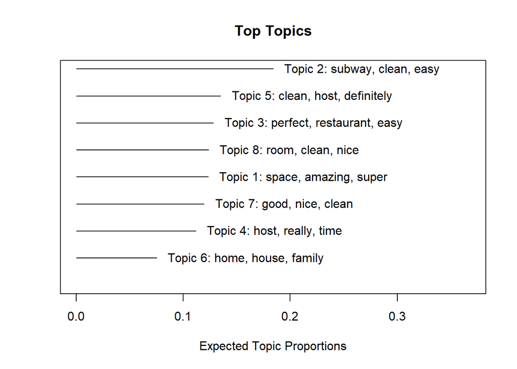

```r
plot(newyorkfit)
```